# Response to Muddy Points

Lecture: Correlation and Simple Linear Regression (Week 10, Day 2)

Author

Emile

Published

March 12, 2026

# Overview

Thank you all for the feedback! The pace ratings were very encouraging: 19 out of 20 responding students rated the pace “about right.” Among the clearest points, several of you highlighted the R² explanation and the walkthrough in R — glad those landed well.

This week’s muddy points span a wide range — from a thoughtful conceptual question about power (not on the lecture topic, but excellent) to very specific R code questions and a subtle issue about what a confidence interval is and isn’t doing in the regression context. All of them are worth unpacking carefully.

**Note**

You do not need to read every section below. Each heading addresses a specific muddy point raised in class. Feel free to focus on the ones most relevant to you.

# Can you be overpowered? Are there statistical consequences?

> *“The typical calculation uses 80%, because this balances cost/resources with statistical value. We have talked a lot about why it is bad to be underpowered, but can you be overpowered? And are there statistical consequences to being overpowered? Is there always a very small possibility of a type II error that prevents you from getting to exactly 100% power?”*

This is a genuinely great question — and the answer is yes on all three counts. Let me address each part.

## Yes, you can be overpowered

Being overpowered means your study has more observations than necessary to detect a clinically meaningful effect at your target power level. This is less talked about than underpowering, but it has real consequences.

The core issue is that **statistical significance is not the same as clinical significance**. With a very large sample, the t-test (or any test) becomes sensitive enough to detect effects so small they are biologically or clinically trivial. Suppose your regression of blood pressure on BMI is fit on $n = 50{,}000$ participants. The slope estimate might be 0.03 mmHg per kg/m² — so small that no clinician would act on it — but with that much data, the p-value is essentially zero and the result is “significant” by any conventional threshold.

This leads to a few practical consequences:

1. **Every test will reject $H_0$, even for trivially small effects.** In an overpowered study, p-values lose their utility as a filter for “interesting” effects.
2. **Resources are wasted.** Recruiting more participants than needed has ethical and financial costs. In clinical trial contexts, exposing additional participants to an experimental treatment they may not benefit from raises ethical concerns.
3. **Effect size interpretation becomes more important.** When $n$ is very large, you should shift your focus from the p-value to the estimated effect size and its confidence interval. Ask: is the estimated slope (or difference, or correlation) large enough to matter in practice?

The practical takeaway is that **the right power target is the one that reflects your actual goals**: be powered to detect the *smallest effect that would be scientifically meaningful*, not just any nonzero effect.

## Power can never literally reach 100%

Your intuition here is exactly right. Recall the definitions:

- **Power** = $1 - \beta$ = probability of rejecting $H_0$ when $H_A$ is true
- **Type II error rate** = $\beta$ = probability of failing to reject $H_0$ when $H_A$ is true

Power reaches 100% only if $\beta = 0$ — that is, only if there is literally zero probability of a Type II error. But as long as the distributions under $H_0$ and $H_A$ overlap at all (which they always do unless the effect is infinite), there is some nonzero probability of making a Type II error.

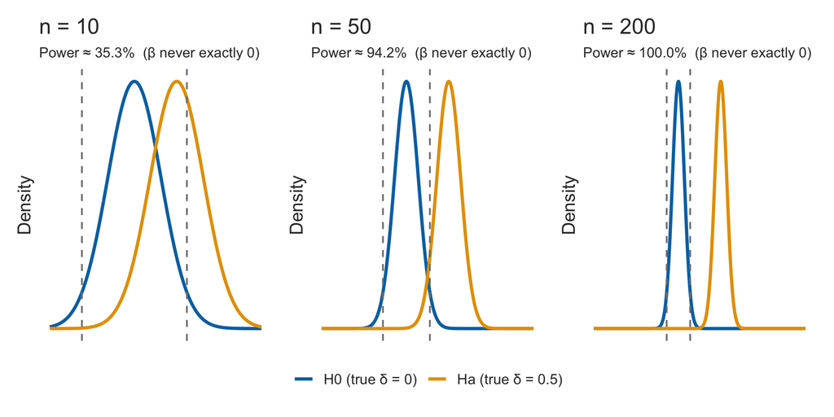

As $n$ increases, the two distributions (under $H_0$ and $H_A$) become narrower and more separated — power climbs toward 100%. But the tails always overlap a little, meaning $\beta$ is always positive. In theory, power = 100% requires $n = \infty$.

In practice, power > 99.9% is achievable with large enough samples, but the question is whether the resources required are justified. The 80% convention is a pragmatic compromise, not a statistical law.

**The practical takeaway**

- Yes, you can be overpowered. The consequence is that trivially small effects become statistically significant, and p-values lose their signal value.
- Type II error rate ($\beta$) is never exactly zero — power = 100% requires infinite sample size. In practice, power grows toward but never reaches 100%.
- The right power target is the one that balances the cost of being wrong (Type II error) with the cost of collecting data. 80% is a common default, but for confirmatory studies with high clinical stakes, 90% is not unusual.

# The R code for the test statistic for slope

> *“I’m a little confused on the R code for the test statistic for slope. Specifically how you had the first code on slide 37 vs. the ‘or directly from the regression table’ on slide 38. Also a little confused on interpretation.”*

Great observation — the two code blocks are doing the same thing via two different routes, and I agree the relationship between them could have been made more explicit in class.

## What the two code blocks are doing

**Step 4 (first code block):**

```r
# Filter the tidy output to get the BMI row, then pull the t-statistic
b1_row <- model_bp %>%
  broom::tidy() %>%
  dplyr::filter(term == "BMI")

t_stat <- b1_row %>% dplyr::pull(statistic)
t_stat
```

```
[1] 3.912713
```

This extracts a single number — the t-statistic for the slope — so we can display the formula:

$$t = \frac{\hat{\beta}_1}{SE_{\hat{\beta}_1}} = \frac{0.698}{0.178} = 3.91$$

The purpose was pedagogical: show explicitly that the t-statistic is computed the same way as in any other t-test — estimate divided by its standard error.

**Step 5 (second code block):**

```r
# The full regression table gives everything at once
model_bp %>%
  broom::tidy(conf.int = TRUE)
```

```
# A tibble: 2 × 7
  term        estimate std.error statistic  p.value conf.low conf.high
  <chr>          <dbl>     <dbl>     <dbl>    <dbl>    <dbl>     <dbl>
1 (Intercept)   98.8       5.05      19.6  2.88e-44   88.8      109.
2 BMI            0.698     0.178      3.91 1.35e- 4    0.345      1.05
```

This shows the complete output table: estimate, standard error, t-statistic, p-value, and confidence interval bounds — all in one place. The t-statistic in the `statistic` column is the same number we pulled above. The p-value in the `p.value` column is the two-sided p-value for testing $H_0: \beta_1 = 0$.

**The short version:** The first block is “here is how the t-statistic is computed, shown step by step.” The second block is “here is where you read it off in practice.” They are not two different approaches — the second contains the first as a column.

## Interpreting the output

For the BMI row:

| Column | Value | Meaning |
| --- | --- | --- |
| `estimate` | $\hat{\beta}_1$ | For each 1 kg/m² increase in BMI, systolic BP increases by this many mmHg, on average |
| `std.error` | $SE_{\hat{\beta}_1}$ | How much $\hat{\beta}_1$ would vary across hypothetical repeated samples |
| `statistic` | $t = \hat{\beta}_1 / SE_{\hat{\beta}_1}$ | How many standard errors the estimated slope is from zero |
| `p.value` | Two-sided p-value | Probability of seeing a t-statistic this extreme (or more) if $\beta_1 = 0$ |
| `conf.low`, `conf.high` | 95% CI for $\beta_1$ | Plausible range of values for the true population slope |

The interpretation of the test: a large $|t|$ (far from zero) → small p-value → evidence against $H_0: \beta_1 = 0$ → evidence that BMI and systolic BP are linearly associated in the population.

**The practical takeaway**

In practice, `tidy(model, conf.int = TRUE)` gives you everything you need in one call. The step-by-step code in Step 4 is there to show what the test statistic *means*, not to suggest that extracting it manually is the normal workflow.

# Sample size for linear regression

> *“The sample size for analyzing linear regression”*

This question is brief, so I want to cover the most likely things you might have been wondering about.

## There is no hard minimum, but there is a mathematical floor

Fitting a regression line requires at least $n = 3$ observations. With $n = 2$, any two points determine a line exactly — the residuals are zero, SSE = 0, and there are no degrees of freedom left for inference ($df = n - 2 = 0$). With $n = 3$, you have one degree of freedom for the residual, which is enough to estimate the residual standard error and run a t-test on the slope — but just barely.

In practice, you need enough observations to:

1. Estimate the slope and intercept reliably
2. Check the LINE conditions (which requires enough points to see patterns in residual plots)
3. Have adequate power to detect a meaningful effect

## A rule of thumb: 10–20 observations per predictor

A commonly cited guideline is **at least 10–20 observations per predictor variable**. For simple linear regression with one predictor, this suggests $n \geq 10$–20 at a minimum, with larger samples giving more stable estimates and more power.

This rule is a rough heuristic, not a statistical law. For large effects ($r \approx 0.7$), you might be well-powered with $n = 15$. For small effects ($r \approx 0.1$), you might need $n = 500$ or more.

## Formal power analysis for regression

The `pwr` package includes `pwr.f2.test()` for regression (and ANOVA-style models), where you specify the effect size as $f^2 = R^2 / (1 - R^2)$. For simple linear regression, this is equivalent to testing the slope.

```r
# Example: power analysis for simple linear regression
# Suppose we anticipate r ≈ 0.30 (a modest association)
r_anticipated <- 0.30
r2_anticipated <- r_anticipated^2
f2 <- r2_anticipated / (1 - r2_anticipated)

pwr::pwr.f2.test(
  u   = 1,       # numerator df = number of predictors = 1 for SLR
  f2  = f2,      # effect size
  sig.level = 0.05,
  power     = 0.80
)
```

```
     Multiple regression power calculation

              u = 1
              v = 79.3268
             f2 = 0.0989011
      sig.level = 0.05
          power = 0.8
```

The output gives `v`, the denominator degrees of freedom ($v = n - 2$ for SLR). So the required sample size is $n = v + 2$. For a correlation of $r \approx 0.30$, you would need approximately $n =$ 82 observations to achieve 80% power at $\alpha = 0.05$.

**The practical takeaway**

- You need $n > 2$ just to fit the model; you need $n \geq 10$–20 to have stable estimates and check assumptions
- For formal planning, use `pwr.f2.test()` with $f^2 = r^2 / (1 - r^2)$, where $r$ is the anticipated correlation
- The required $n$ depends heavily on the anticipated effect size. Small anticipated correlations require much larger samples

# Why can’t the confidence interval predict where a new individual will be?

> *“I’m still confused on the theory behind why the CI isn’t able to predict where a new individual will be. Doesn’t the CI we calculate provide a std dev that represents the variability around that mean line, which then can be used to predict the new sample value?”*

This is a subtle and important conceptual question — and the confusion it reflects is extremely common. Let me address it carefully.

## A likely source of the confusion: the SE for $\hat{\beta}_1$

It’s worth pausing on your phrasing — “the CI we calculate provides a std dev that represents the variability around that mean line.” I want to make sure we’re clear on which CI and which standard deviation is doing what.

When we run `tidy(model_bp, conf.int = TRUE)`, we get a CI for $\beta_1$ (the slope). The `std.error` column for that row is $SE_{\hat{\beta}_1}$ — the standard error of the slope estimate. This tells you **how precisely we estimated the slope**: how much $\hat{\beta}_1$ would vary if we re-sampled and re-fit the model repeatedly. It is uncertainty about the *angle* of the line, not about scatter around it.

The quantity that captures how much individual observations scatter around the true line is $\sigma$ — the residual standard deviation. In R, this is `sigma` in `glance()` output. These two quantities measure entirely different things:

| Quantity | Symbol | What it measures | Found in R |
| --- | --- | --- | --- |
| SE of slope | $SE_{\hat{\beta}_1}$ | Precision of our slope estimate | `tidy()` → `std.error` for BMI row |
| Residual SD | $\hat{\sigma}$ | Typical scatter of individuals around the line | `glance()` → `sigma` |

```r
# SE for slope -- how well we estimated the line's angle
tidy(model_bp) %>% filter(term == "BMI") %>% pull(std.error)
```

```
[1] 0.1782703
```

```r
# Residual SD -- how much individuals vary around the line
glance(model_bp) %>% pull(sigma)
```

```
[1] 17.45309
```

Notice how much larger `sigma` is than `std.error`. That gap is precisely why the prediction interval is so much wider than the CI for mean response — individual scatter ($\hat{\sigma}$) dwarfs the uncertainty in the line itself. The CI for $\beta_1$ tells you the line is well-estimated; it says nothing about how spread out individual patients are around it.

## What the confidence interval for mean response actually captures

The CI for mean response at a given $X^*$ answers the question: **“Where is the true regression line at $X^*$?”** That is, it is an interval for the *population mean of $Y$* among all individuals with $X = X^*$.

The width of this CI reflects **uncertainty about the estimated regression line** — specifically, uncertainty in both $\hat{\beta}_0$ and $\hat{\beta}_1$ arising from the fact that we estimated them from a sample. If we collected a new sample of the same size and re-fit the line, we’d get a slightly different $\hat{\beta}_0$ and $\hat{\beta}_1$, and therefore a slightly different predicted value at $X^*$. The CI captures that sampling variability.

Crucially, the CI does **not** capture the variability of individual observations around the true line. That variability is described by $\sigma^2$ — the residual variance — and it represents the fact that even if you knew $\beta_0$ and $\beta_1$ exactly, individual people at BMI = 30 would still have blood pressures scattered above and below the line.

## The two sources of uncertainty

When predicting where a *new individual* will fall, there are two sources of uncertainty that must both be accounted for:

| Source | What it reflects | Captured by |
| --- | --- | --- |
| **Uncertainty about the line** | We estimated $\hat{\beta}_0$ and $\hat{\beta}_1$ from a sample — the true line might be a bit higher or lower | CI for mean response |
| **Individual variation around the line** | Even at the *true* line, individuals vary — $\epsilon \sim N(0, \sigma^2)$ | Residual variance $\sigma^2$ |

The **prediction interval** combines both:

$$PI = \hat{Y} \pm t^*_{n-2} \cdot \sqrt{SE_{\hat{\mu}}^2 + \hat{\sigma}^2}$$

The $SE_{\hat{\mu}}^2$ term is what drives the CI for mean response. The $\hat{\sigma}^2$ term is what gets added for individual prediction.

The CI for mean response uses only the $SE_{\hat{\mu}}^2$ term — it says nothing about how far individuals scatter around the mean.

## An analogy

Imagine you are trying to predict the height of the next OHSU PhD student to walk through the door.

- The **CI for mean response** is like knowing the *average* height of OHSU PhD students with great precision. With a large enough dataset, you can be very confident about the average — but that confidence tells you nothing about where any individual will fall.
- The **prediction interval** is like trying to predict *this specific person’s* height. Even if you know the average exactly, individual heights vary by several inches. The prediction interval must account for that scatter.

More data narrows the CI for mean response (better estimates of the line), but the prediction interval never collapses to a point — because $\sigma^2$, the individual variation around the true line, is a feature of the population, not a consequence of our sample size.

## In R

```r
# CI for mean response at BMI = 30
predict(model_bp, newdata = tibble(BMI = 30), interval = "confidence")
```

```
       fit      lwr      upr
1 119.7562 116.8847 122.6277
```

```r
# Prediction interval for a new individual at BMI = 30
predict(model_bp, newdata = tibble(BMI = 30), interval = "prediction")
```

```
       fit      lwr      upr
1 119.7562 85.16867 154.3437
```

The CI width is 5.7 mmHg. The prediction interval width is 69.2 mmHg — much wider, because it must also account for how much individuals vary around the line.

Notice that both are centered at the same point estimate ($\hat{Y}$). The difference is entirely in what sources of uncertainty are being captured.

**The practical takeaway**

- The CI for mean response captures **uncertainty about where the line is** (sampling variability in $\hat{\beta}_0$ and $\hat{\beta}_1$). It answers: “What is the average BP for *all people* with BMI = 30?”
- The prediction interval captures **uncertainty about where the line is** *plus* **individual variation around the line** ($\sigma^2$). It answers: “What BP would *this specific new person* with BMI = 30 have?”
- Adding more data narrows the CI for mean response (better estimates of the line), but the prediction interval cannot shrink below the width determined by $\sigma^2$ — because individual variation is a real feature of the population, not a result of estimation error.

# Summary

- **Overpowering** is a real phenomenon: when $n$ is very large, even negligible effects become statistically significant. The fix is to anchor your power analysis to the smallest *clinically meaningful* effect, not just any nonzero effect. And yes — Type II error rate ($\beta$) is never exactly zero; power = 100% requires infinite sample size.
- **The two R code blocks for the slope test** are doing the same thing via different routes. The first extracts the t-statistic to show the formula; the second reads the full regression table. In practice, `tidy(model, conf.int = TRUE)` gives you everything in one call.
- **Sample size for regression** has no magic number, but a rough guideline is 10–20 observations per predictor. For formal planning, use `pwr.f2.test()` with $f^2 = r^2 / (1 - r^2)$, where $r$ is the anticipated Pearson correlation.
- **The CI for mean response is not a prediction interval.** The CI captures uncertainty about where the *line* is. Predicting an individual also requires accounting for scatter around the line ($\sigma^2$), which is why the prediction interval is always wider. More data narrows the CI but cannot eliminate individual variation.